# BIOSTAT 203B: Homework 4

Chad Pickering

3/16/2018

#### We first connect to spark, the data, etc.

```r
if (!"gridExtra" %in% rownames(installed.packages())){
  install.packages("gridExtra", repos="http://cran.rstudio.com/")
}

if (!"viridis" %in% rownames(installed.packages())){
  install.packages("viridis", repos="http://cran.rstudio.com/")
}

library(sparklyr)
library(dplyr)
library(ggplot2)
library(lubridate)
library(gridExtra)
library(viridis)

Sys.setenv(SPARK_HOME="/usr/lib/spark")
config <- spark_config()
sc <- spark_connect(master = "yarn-client", config = config)
flights_tbl <- tbl(sc, 'flights')
airports_tbl <- tbl(sc, 'airports')
airlines_tbl <- tbl(sc, 'airlines')
```

### 1. Map the top 10 busiest airports (in 1995). Size of dots should reflect the number of flights through that destination.

#### “Busiest” is defined as the sum of flights arriving and departing a particular airport per unit time.

Chicago/O’Hare, Dallas/Ft. Worth, Atlanta, and LAX were the top 4 busiest U.S. airports in 1995 according to our metric.

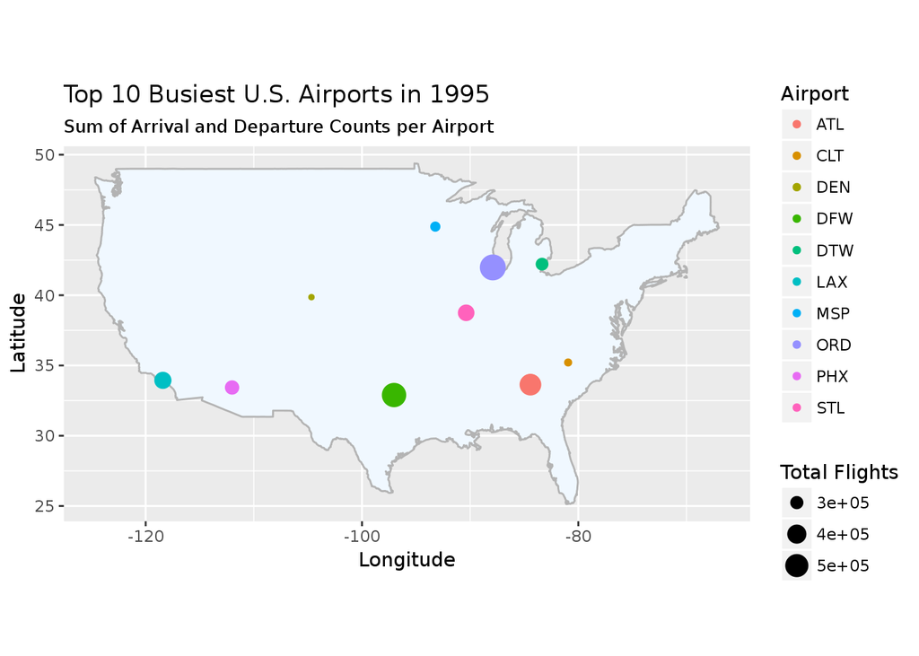

### 2. Map the top 10 busiest direct routes. Size of lines should reflect the number of flights through that route.

In 1995, all of the top 10 busiest direct airline routes had their converses in the top 10 as well, as shown by the map. Destinations close to each other that are more popular pack the top 10. For example, Las Vegas to LAX and vice versa was the busiest pair.

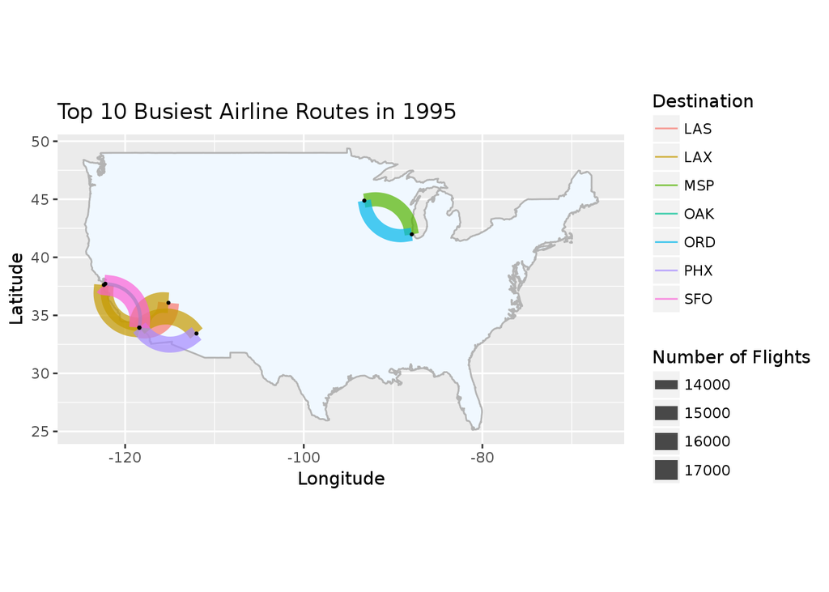

### 3a. Reproduce the LAX time series plot. Visualize and explain some prominent features you observe. For example, what happened at points 1-5?

#### The reproduction:

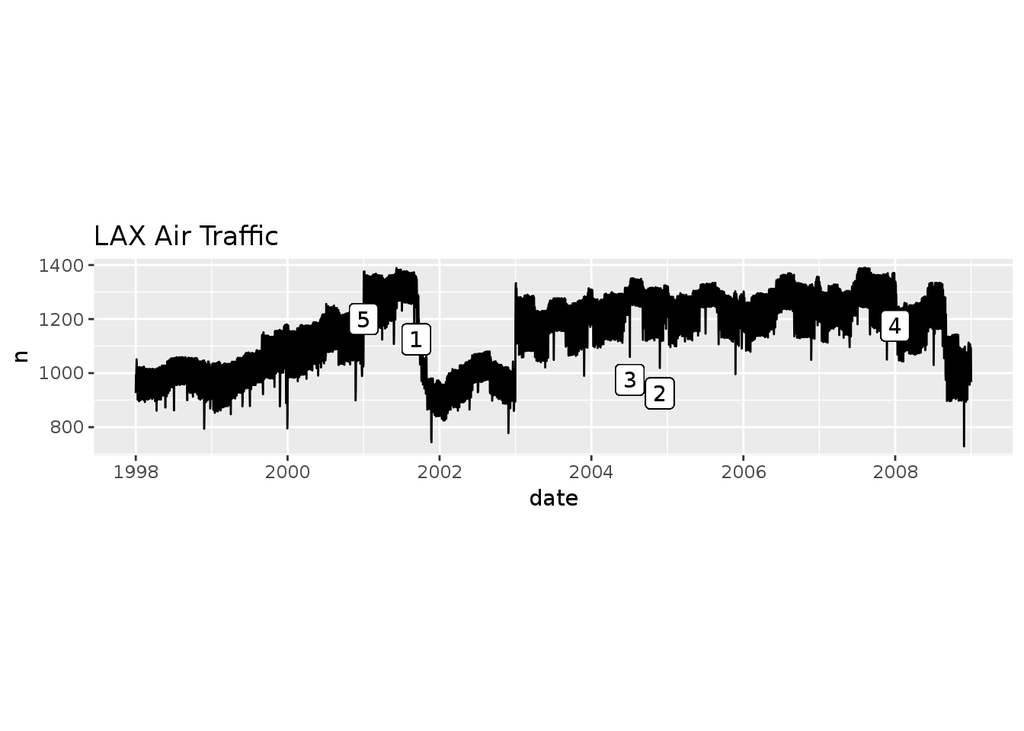

#### Prominent feature #1:

The 9/11 attacks on September 11, 2001 greatly reduced the number of planes flying in and out of LAX. However, the drop-off is not completely sudden; it takes a few weeks to stabilize again.

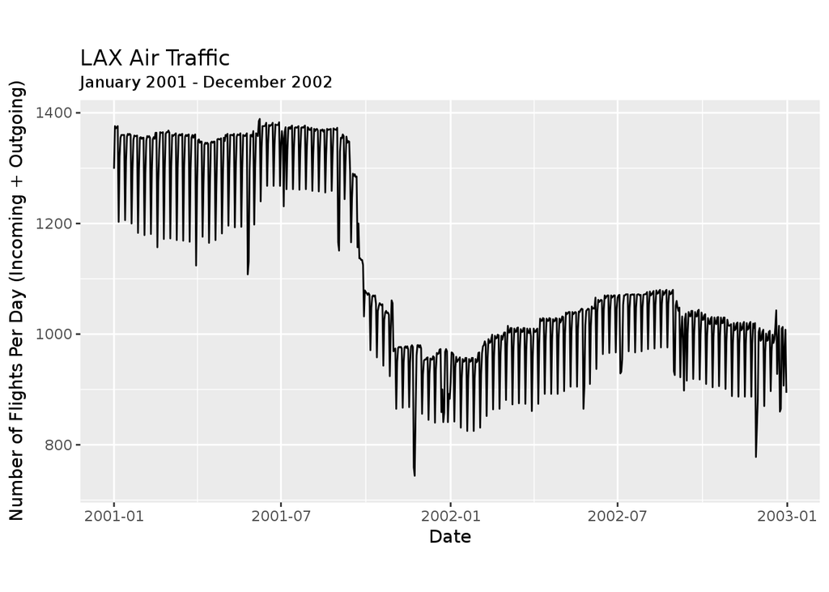

#### Prominent features #2 and #3:

Prominent feature #2 is the dip at the end of November, likely Thanksgiving - air traffic decreases because of holiday closures and activities. Prominent feauture #3 is the dip at the beginning of July - Independence Day - much for the same reasons noted above.

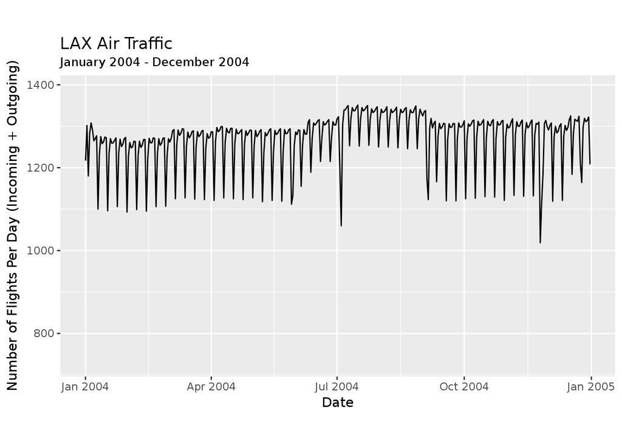

#### Prominent feature #4:

The Great Recession began in 2007, and the subtle drop at the beginning of 2008 may be because airports across the country implemented new policies to reduce the number of aircrafts in operation with the hopes of decreasing cost. A larger dip happens in summer 2008 after a small rebound.

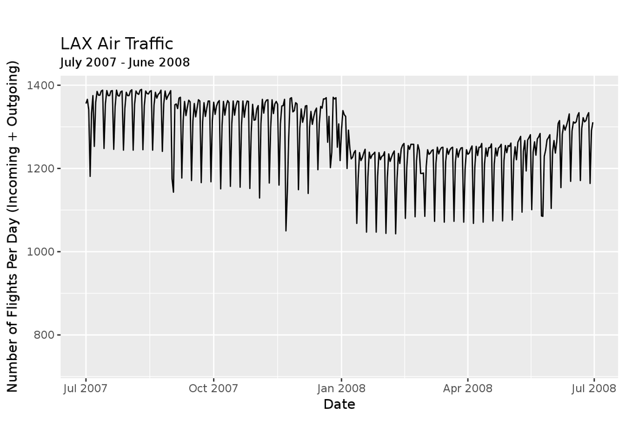

#### Prominent feature #5:

It seems like there was a policy change that took effect on January 1, 2001 that increased the number of aircraft in operation. This trend remains constant throughout 2001 until the 9/11 attacks.

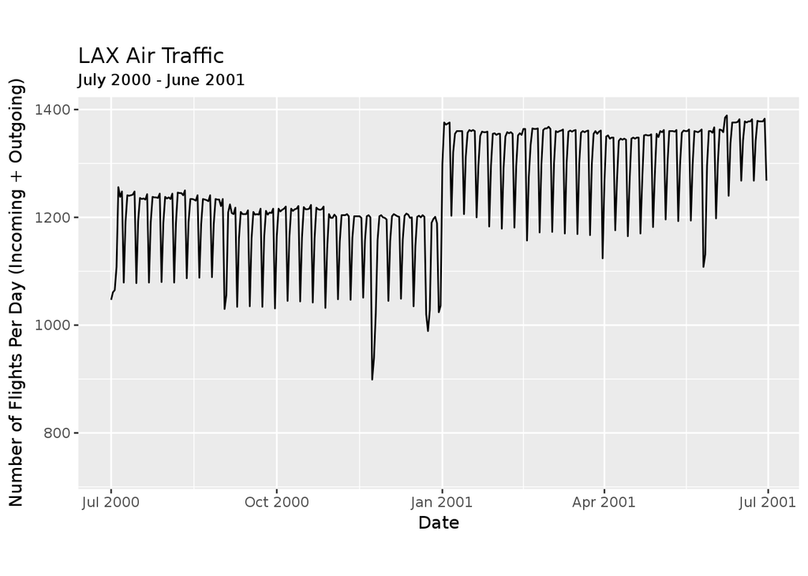

### 3b. Visualize and explain seasonal effects.

First, eliminate the yearly effect. I generate a mean count per year, and center each day’s count to the corresponding year’s mean.

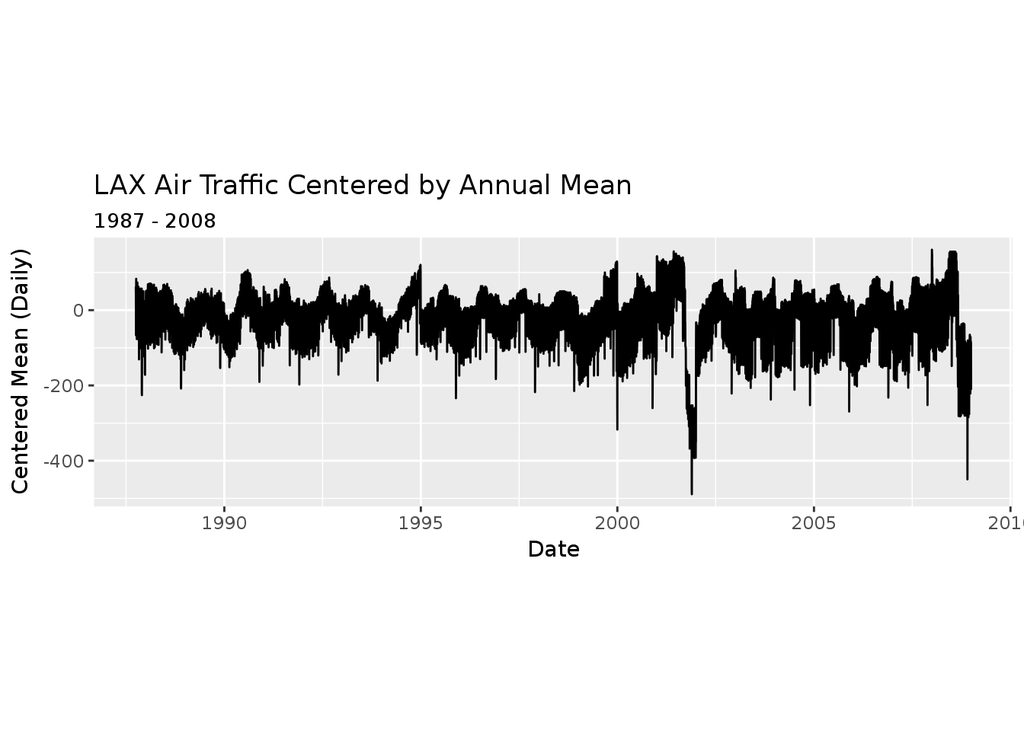

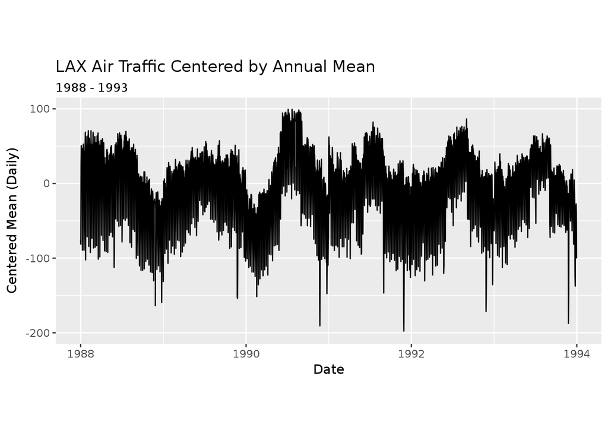

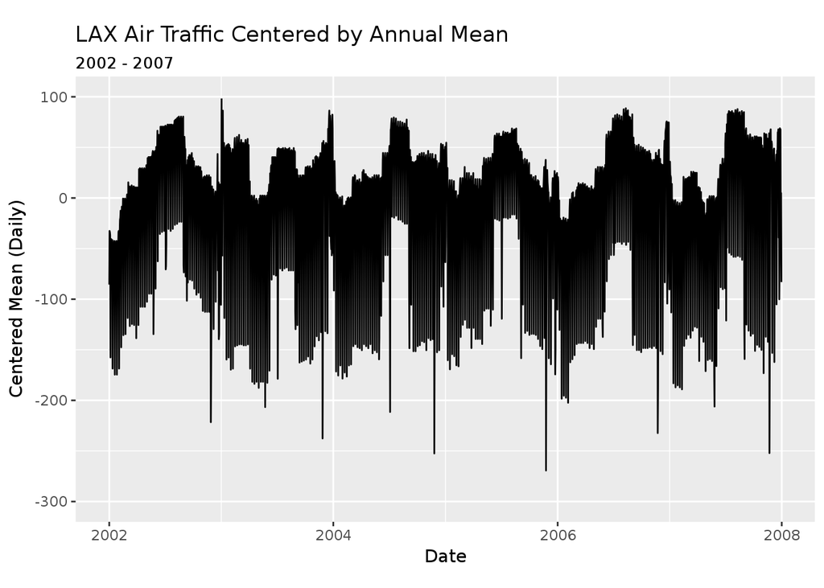

Going further, we can average over each unique day of a year in the range 1987-2008 to see the average trend and quantify the typical deviance in number of operating aircrafts during any season relative to average. There are more flights per day on average from Post-Memorial Day through Labor Day as compared to the rest of the year. This makes summer the peak of the annual seasonality behavior, and winter months (including December) the trough. National holidays are local minima.

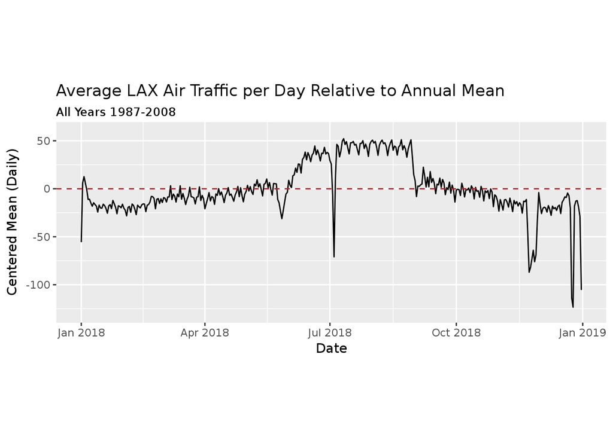

### 3c. Visualize and explain weekly effects.

First, let’s zoom into two segments of the plot from 3a. Both plots show the overarching weekly trend, a relatively constant number of aircrafts over the weekdays with a substantial drop on Saturday and a partial recovery on Sunday. Both plots shown cover September and October, the top from 2000 (pre-9/11) and the bottom from 2007 (post-9/11). We can see that Tuesdays in the 2007 plot feature less flights on average than the other weekdays; this is a difference in trend from the pre-9/11 plot.

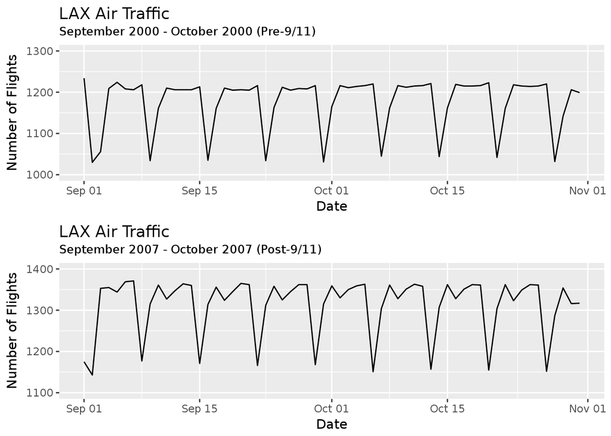

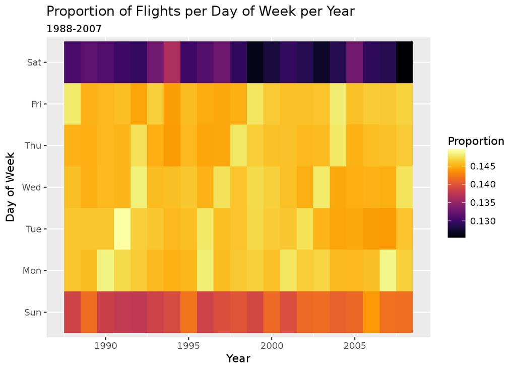

### 3d. Map top 10 destinations from LAX. Size of dots should reflect the number of flights from LAX to that destination.

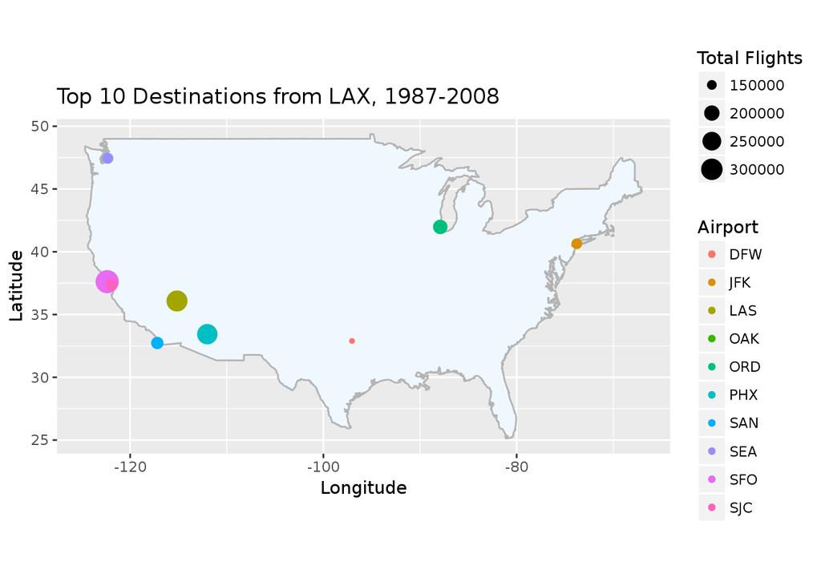

### 4. Build a predictive model for the arrival delay (`arrdelay`) of flights flying from LAX. You are allowed to use a maximum of 5 predictors.

I am subsetting the dataset to include only flights in 2003 and after - predictions will be more indicative of current conditions.

### 5. Visualize and explain any other information you want to explore.

### Question: Did flights have increased departing delays on average after 9/11 as compared to before? Is there a difference between JFK (near the attack) and LAX (not near the attack)?

According to the two plots below, JFK airport did not see a significant difference in mean departure delay between the two time intervals. However, it looks as though LAX experienced lower average departure delay with lower variance after the attacks. This was an unexpected result.

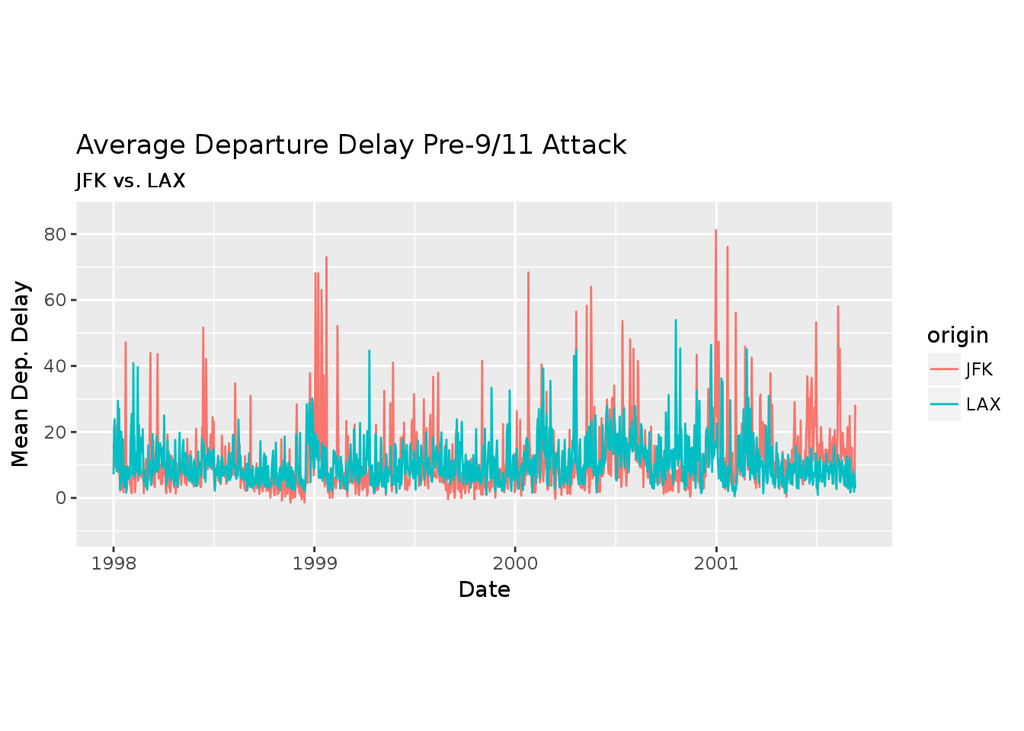

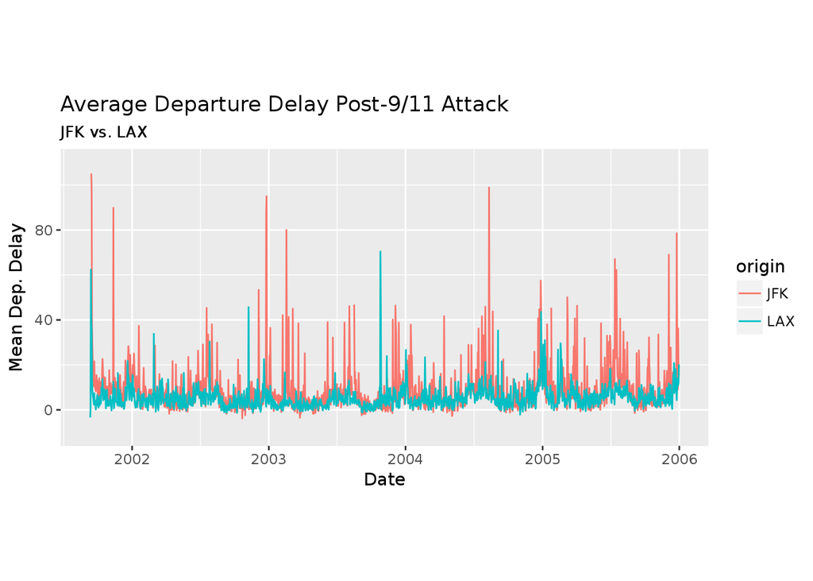

Isolating LAX, we can see the rather distinct change in overall mean departure delay and decrease in variability after the attacks. We do not see such a trend with at the JFK airport.

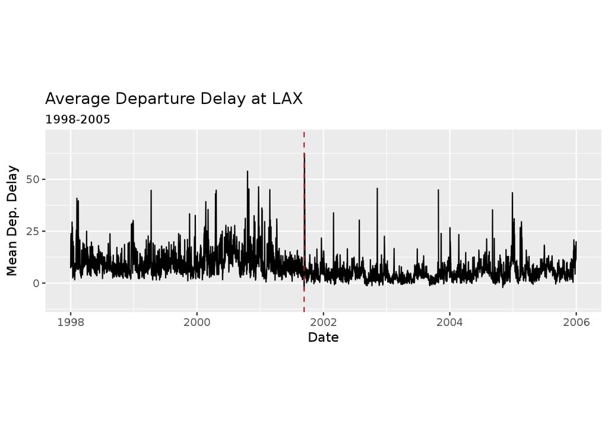

Lastly, just looking at a table of mean departure time per year for the two airports makes the distinction clear.

```
## # A tibble: 16 x 3
## # Groups:   origin [2]
##    origin  year mean_depdelay
##    <chr>  <int>         <dbl>
##  1 JFK     1998          8.56
##  2 JFK     1999          8.95
##  3 JFK     2000         11.2
##  4 JFK     2001         13.9
##  5 JFK     2002          7.19
##  6 JFK     2003          6.78
##  7 JFK     2004          8.60
##  8 JFK     2005         10.7
##  9 LAX     1998          9.78
## 10 LAX     1999          9.52
## 11 LAX     2000         13.4
## 12 LAX     2001          8.47
## 13 LAX     2002          4.93
## 14 LAX     2003          3.77
## 15 LAX     2004          5.98
## 16 LAX     2005          6.56
```